# Employee Attrition Dataset: Chris Vallier

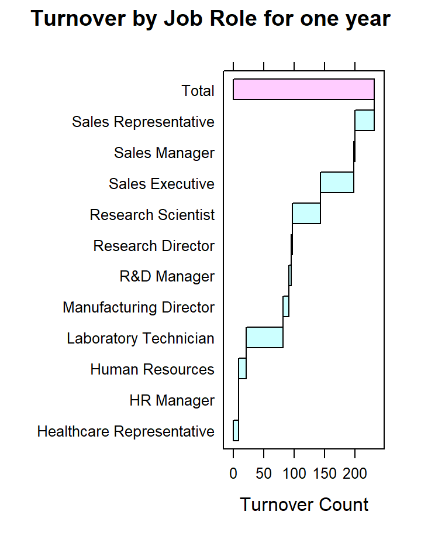

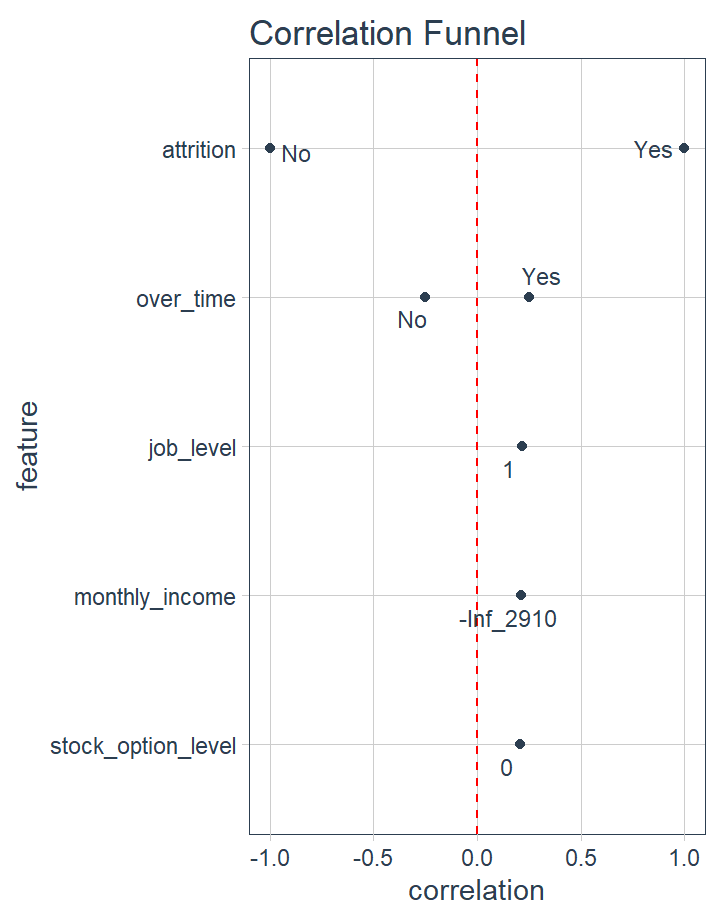

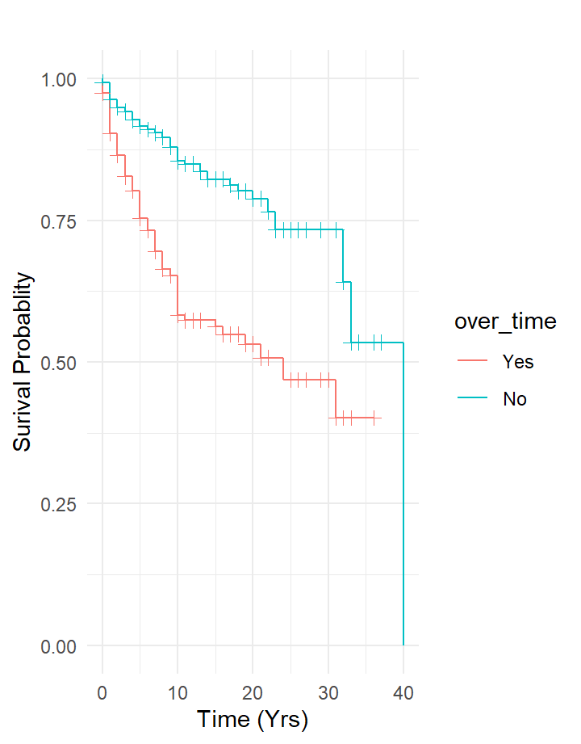

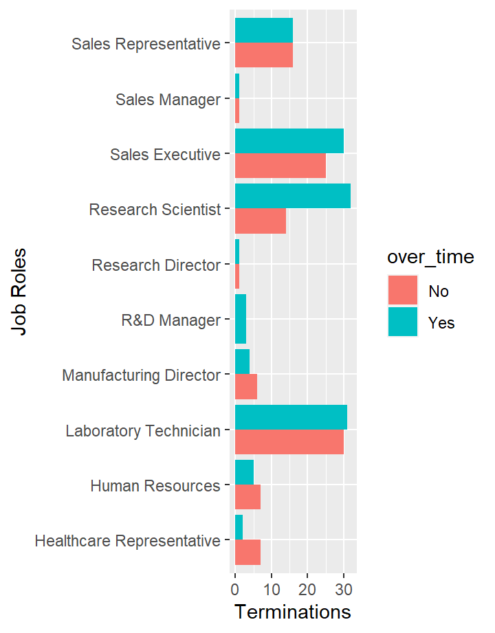

[figure not shown]

### Problem Summary

#### Employee attrition is an important business problem. Losing key employees causes loss of productivity and the company money. Understanding this problem is key before taking action and preventing it proactively when and where possible. **This analysis is attempting to address one or two key drivers of turnover and develop an informed recommendation**.

#### The dataset was provided to the public in 2017 by IBM to aspiring and current data scientists. The data scientist is to perform a predictive classification task on employee attrition. This dataset is set up with 35 variables and 1,399 employee records in a CSV file. Many of the variables include what you would find or could derive in an HR Reporting system.

#### The analysis performed here is not to predict future employee turnover, but to derive insights and recommendations from the data. So, executives can make informed decisions and create action plans.

#### Another important note is that the dataset doesn’t include hire date nor termination date. In place of these missing variables tenure in years is used in its place. One cannot tell the time period in which the attrition has taken place, but for this analysis one year is assumed for simplicity.

### Current Analysis

#### **1.** At IBM attrition is 16.6% (232 terms / 1399 employees) throughout the year. This is a higher than average turnover when compared to the software industry, which typically is around 13.3%.

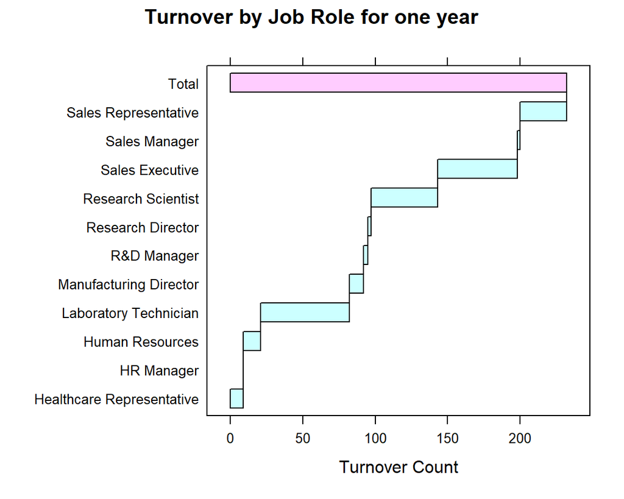

#### **2.** The top four job roles make up ~84% of the turnover: Laboratory Technician, Sales Executive, Research Scientist and Sales Representative.

Turnover Analysis by Department and Job Role

| Department | Job Role | Turnover % | Turnover Count | Avg. Tenure | Avg. Attrition Tenure |
| --- | --- | --- | --- | --- | --- |
| Research & Development | Laboratory Technician | 25% | 61 | 5 | 3 |
| Sales | Sales Executive | 18% | 55 | 7 | 7 |
| Research & Development | Research Scientist | 16% | 46 | 5 | 4 |
| Sales | Sales Representative | 42% | 32 | 3 | 2 |
| Human Resources | Human Resources | 24% | 12 | 5 | 4 |
| Research & Development | Manufacturing Director | 7% | 10 | 8 | 9 |
| Research & Development | Healthcare Representative | 7% | 9 | 8 | 11 |
| Research & Development | R&D Manager | 6% | 3 | 14 | 7 |
| Research & Development | Research Director | 3% | 2 | 11 | 26 |
| Sales | Sales Manager | 5% | 2 | 15 | 28 |
| Human Resources | HR Manager | 0% | 0 | 17 | NaN |

### Root Cause & Insight Analysis

##### **1. The correlation analysis shows overtime has the most influence of attrition**, followed by **junior job level (1)** and **monthly income of less than $2,910** and for employees who have **no stock options**. Of these factors, overtime is the most controllable factor by management and will be considered for further analysis and recommendations.

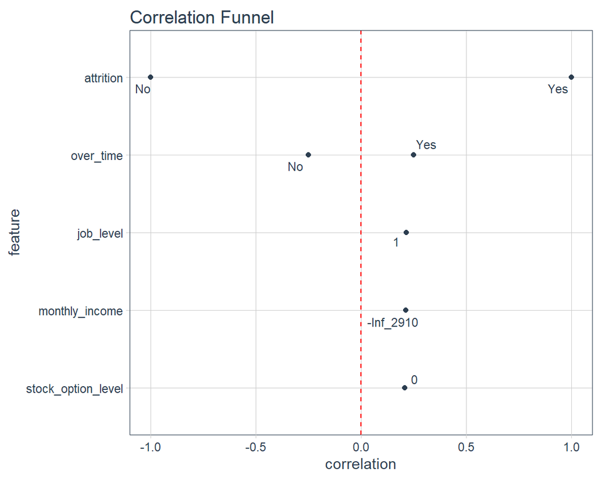

#### **2.** Survival Analysis shows a higher probability of leaving much sooner when an employee works overtime vs no overtime.

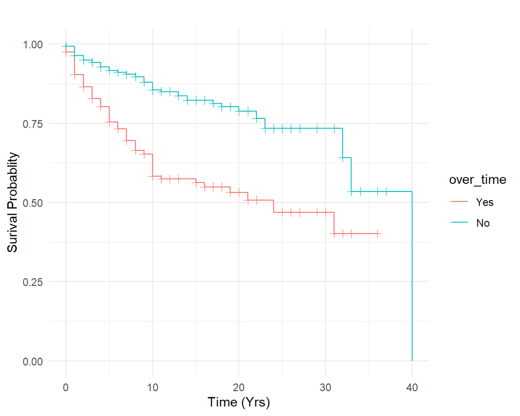

#### **3.** The job roles that are impacted the most by overtime are Sales Representative, Human Resources, and Laboratory Technician. These roles related to overtime accounted for 45% of the turnover count.

Employee Overtime Analysis

| Department | Job Role | Overtime % | Overtime Count | Turnover Count | Turnover/Overtime Ratio | Avg. Attrition Tenure |
| --- | --- | --- | --- | --- | --- | --- |
| Sales | Sales Representative | 30% | 23 | 32 | 1.4 | 2 |
| Human Resources | Human Resources | 22% | 11 | 12 | 1.1 | 4 |
| Research & Development | Laboratory Technician | 24% | 58 | 61 | 1.1 | 3 |
| Sales | Sales Executive | 30% | 92 | 55 | 0.6 | 7 |
| Research & Development | Research Scientist | 34% | 94 | 46 | 0.5 | 4 |
| Research & Development | Healthcare Representative | 28% | 35 | 9 | 0.3 | 11 |
| Research & Development | Manufacturing Director | 27% | 37 | 10 | 0.3 | 9 |
| Research & Development | R&D Manager | 25% | 13 | 3 | 0.2 | 7 |
| Sales | Sales Manager | 27% | 10 | 2 | 0.2 | 28 |
| Research & Development | Research Director | 29% | 22 | 2 | 0.1 | 26 |
| Human Resources | HR Manager | 30% | 3 | 0 | 0.0 | NaN |

### Recommendations

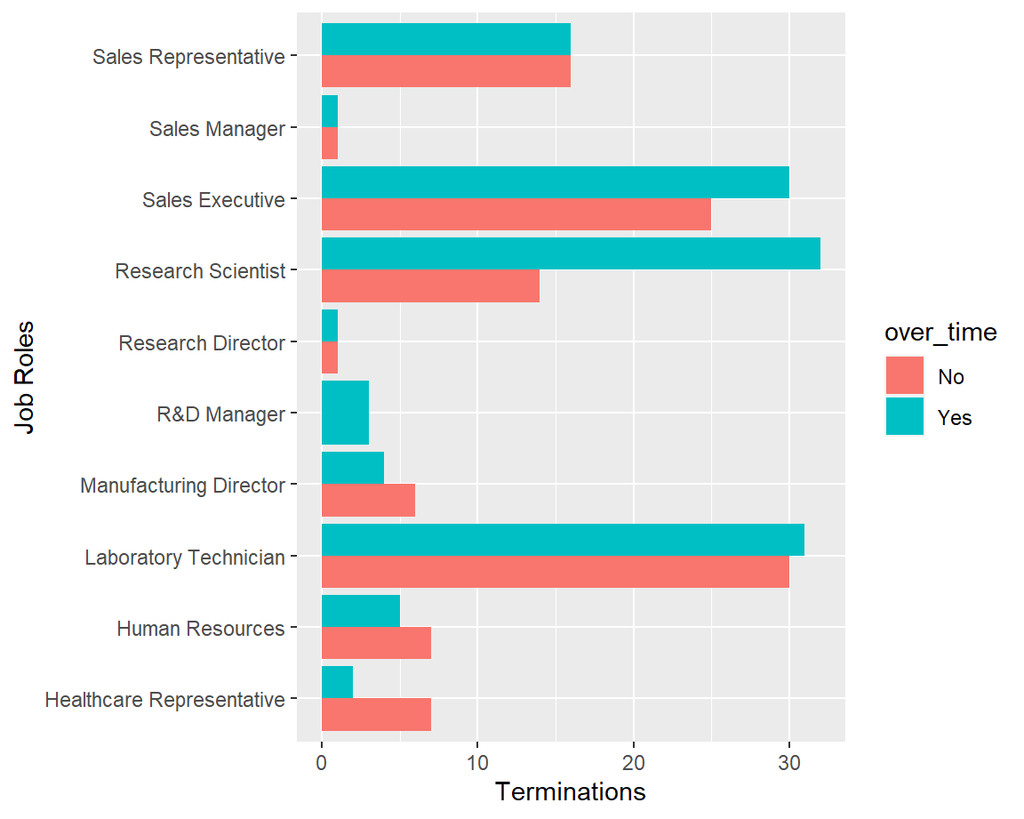

[figure not shown]

#### **3.** The odds of turnover given overtime are 4.4 higher than if you did not work overtime. For certain roles, odds increase of turnover are over a five fold risk of attrition for the 3 job roles: Sales Representative, Laboratory Technician and Human Resources. **I would recommend to management restricting overtime when and where necessary for all roles**. I would also recommend more in depth analysis using exit survey responses for Sales Representative, Human Resources, and Laboratory Technician to better understand the drivers of the high turnover. I would also meet with senior leadership and possibly recommend stay interviews for any employee that is a high concern of leaving.

| predictor | oddsratio | ci_low (2.5) | ci_high (97.5) | increment |
| --- | --- | --- | --- | --- |
| over_timeYes | 4.427 | 3.249 | 6.058 | Indicator variable |
| job_roleHR Manager | 0.000 | 0.000 | 0.000 | Indicator variable |
| job_roleHuman Resources | 5.112 | 1.940 | 13.914 | Indicator variable |
| job_roleLaboratory Technician | 5.099 | 2.496 | 11.580 | Indicator variable |
| job_roleManufacturing Director | 1.019 | 0.390 | 2.700 | Indicator variable |
| job_roleR&D Manager | 0.822 | 0.174 | 2.971 | Indicator variable |
| job_roleResearch Director | 0.331 | 0.049 | 1.356 | Indicator variable |
| job_roleResearch Scientist | 2.426 | 1.176 | 5.538 | Indicator variable |
| job_roleSales Executive | 2.865 | 1.405 | 6.486 | Indicator variable |
| job_roleSales Manager | 0.738 | 0.107 | 3.129 | Indicator variable |
| job_roleSales Representative | 10.768 | 4.782 | 26.378 | Indicator variable |